# The Problem We All Deal With

Andrew Ba Tran

1/28/2017

## Case Study Exploration

This analysis is meant to accompany the story [The Problem We All Live With](https://www.thisamericanlife.org/radio-archives/episode/562/the-problem-we-all-live-with) from episode 562 of **This American Life**.

We’ll be exploring the test score gaps between black and white students and their relationship with socioeconomic factors such as income and population. The data used in this analysis comes from the [Stanford Education Data Archive](http://news.stanford.edu/2016/04/29/local-education-inequities-across-u-s-revealed-new-stanford-data-set/).

## Downloading and loading the data

```r
#if(!exists("data/district%20gaps%20(pooled%20year,%20grade%20and%20sub)_v1_1.csv")) {
#  download.file("https://stacks.stanford.edu/file/druid:db586ns4974/district%20gaps%20(pooled%20year,%20grade%20and%20sub)_v1_1.csv", "data/district%20gaps%20(pooled%20year,%20grade%20and%20sub)_v1_1.csv")
#}
test_gaps <- read.csv("data/district%20gaps%20(pooled%20year,%20grade%20and%20sub)_v1_1.csv", stringsAsFactors=F)

#if(!exists("data/codebook_achievement_v1point1.xlsx")) {
#  download.file("https://stacks.stanford.edu/file/druid:db586ns4974/codebook_achievement_v1point1.xlsx", "data/codebook_achievement_v1point1.xlsx")
#}
tr_dictionary <- read_excel("data/codebook_achievement_v1point1.xlsx", sheet=11)

#if(!exists("data/district%20covariates%20from%20acs%20and%20ccd%20master_v1_1.csv")) {
#  download.file("https://stacks.stanford.edu/file/druid:db586ns4974/district%20covariates%20from%20acs%20and%20ccd%20master_v1_1.csv", "data/district%20covariates%20from%20acs%20and%20ccd%20master_v1_1.csv")
#}
covariates <- read.csv("data/district%20covariates%20from%20acs%20and%20ccd%20master_v1_1.csv", stringsAsFactors=F)

#if(!exists("data/codebook_covariates_v1_1.xlsx")) {
#  download.file("https://stacks.stanford.edu/file/druid:db586ns4974/codebook_covariates_v1_1.xlsx", "data/codebook_covariates_v1_1.xlsx")
#}
cv_dictionary <- read_excel("data/codebook_covariates_v1_1.xlsx", sheet=1)
```

Researchers at Stanford gathered up data to compare communities’ test scores with their socioeconomic qualities.

The data sets we’ve downloaded and created are covariates and test_gaps. We’ve also downloaded their accompanying data dictionaries.

Let’s take a tour of the data we’ve downloaded, starting with `test_gaps`.

```r
str(test_gaps)
```

```
## 'data.frame':    4450 obs. of  9 variables:
##  $ leaid      : int  100005 100006 100007 100008 100011 100012 100013 100030 100060 100090 ...
##  $ leaname    : chr  "ALBERTVILLE CITY" "MARSHALL COUNTY" "HOOVER CITY" "MADISON CITY" ...
##  $ fips       : chr  "AL" "AL" "AL" "AL" ...
##  $ stateabb   : chr  "AL" "AL" "AL" "AL" ...
##  $ gapblk     : num  NA NA 0.939 0.937 0.623 ...
##  $ gapseblk   : num  NA NA 0.0137 0.0217 0.0361 ...
##  $ gaphsp     : num  0.53 0.249 0.952 0.724 0.592 ...
##  $ gapsehsp   : num  0.0224 0.0248 0.0298 0.0839 0.1567 ...
##  $ racepercent: num  0.999 1 1 0.991 0.991 ...
```

**Note:** We’re looking specifically at data pulled from the 11th sheet of the Excel workbook file. Some things Excel does well and we’ll continue to use it when it’s the fastest option.

It looks like each row represents a different school district.

What do those variable names mean, like `leaid` and `gapblk`?

Well, open up the data dictionary file `tr_dictionary` either by clicking the grid on the right of it in the **Environment** tab or typing `View(tr_dictionary)`.

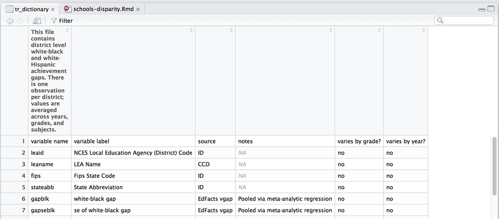

Viewing table in RStudio

Alright, we know that `gapblack` is **white-black gap** and other notes like the metric was “Pooled via meta-analytic regression”. And `leaid` is the code for the District— which will be important for us to use later when we’re joining different data sets.

## Test gaps data exploration

Let’s do some quick summaries. Which states have the highest gaps?

We’re going to use the `dplyr` package. It simplifies wrangling data by using verbs.

Let’s take a quick look at the `test-gaps` dataframe.

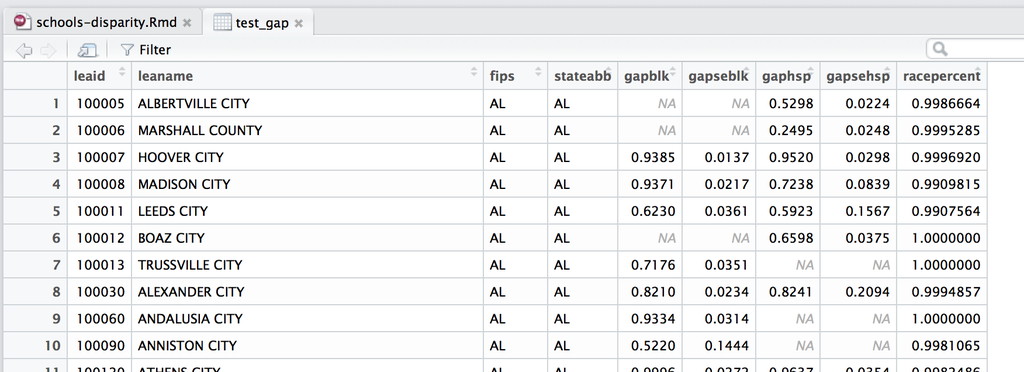

Viewing test-gap table in RStudio

The columns we want to play around with are `stateabb` and `gapblk`.

We’ll also be using the `DT` library so we can present these tables of data easier. It will be easier for us to search and will add pagination to tables for a much better presentation.

```r
library(DT)

state_gap_summary <- test_gaps %>%
  group_by(stateabb) %>%
  summarise(average_gap = mean(gapblk, na.rm=T)) %>%
  arrange(-average_gap)

datatable(state_gap_summary)
```

|  | stateabb | average_gap |
| --- | --- | --- |
| 1 | DC | 1.4563 |
| 2 | VT | 1.1299 |
| 3 | ME | 0.879566666666667 |
| 4 | MN | 0.857971739130435 |
| 5 | WI | 0.831887179487179 |
| 6 | SD | 0.80205 |
| 7 | IA | 0.770095454545455 |
| 8 | NC | 0.749511340206186 |
| 9 | CT | 0.7362 |
| 10 | FL | 0.727071428571429 |

[output cut: 41 more lines]

It looks like DC, Vermont, and Maine have some of the largest gaps between white and black test scores.

That’s interesting by itself, sure, but not enough. We’ve figured out the average gap by state but **compared to what?** aside from each other?

That’s what we’ve got the covariates of demographic information for.

## Covariates data exploration

Let’s see if there’s any sort of relationship between the gaps and anything else we can find.

Let’s take a look at the structure of the covariates dataframe.

```r
str(covariates)
```

```
## 'data.frame':    13069 obs. of  168 variables:
##  $ leaid            : int  100005 100006 100007 100008 100011 100012 100013 100030 100060 100090 ...
##  $ leaname          : chr  "ALBERTVILLE CITY" "MARSHALL COUNTY" "HOOVER CITY" "MADISON CITY" ...
##  $ fips             : int  1 1 1 1 1 1 1 1 1 1 ...
##  $ stateabb         : chr  "AL" "AL" "AL" "AL" ...
##  $ metroid          : int  10700 10700 13820 26620 13820 10700 13820 10760 NA 11500 ...
##  $ metromicro       : int  2 2 1 1 1 2 1 2 NA 1 ...
##  $ czid             : int  558 558 21 120 21 558 21 190 60 303 ...
##  $ countyid         : int  1095 1095 1073 1089 1073 1095 1073 1123 1039 1015 ...
##  $ cdcode           : int  104 104 106 105 106 104 106 103 102 103 ...
##  $ urban            : int  0 0 0 0 0 0 0 0 0 0 ...
##  $ avgrdall         : num  304 442 996 658 121 ...
##  $ avgrdwht         : num  191.4 374.9 641.2 444 75.8 ...
##  $ avgrdblk         : num  5.74 4.81 227.92 133.73 29.83 ...
##  $ avgrdhsp         : num  104.8 59.9 59.5 21.5 13.9 ...
```

[output cut: 86 more lines]

Wow, alright, that’s a lot of variables.

Check out `View(cv_dictionary)` and you’ll see the definitions of more than 160 different factors measuring demographics in a school district.

Which of these should we compare to the gaps to see if there’s a correlation?

What socioeconomic factors of a school district might affect the gap between scores based on what you’ve heard in the TAL podcast?

Think like a scientist. Come up with a list of ideas and test them.

Alright, now think…

Done? Did you come up with **income level** and **level of integration**? Great!

If you search through the `cv_dictionary` you can see those variables are called `incVblkwht` and `hswhtblk`.

Let’s do some more summaries.

```r
cv_summary <- covariates %>%
  group_by(stateabb) %>%
  summarise(avg_income_gap=mean(incVblkwht, na.rm=T), avg_segregation_score=mean(hswhtblk, na.rm=T)) %>%
  arrange(-avg_income_gap)

datatable(cv_summary)
```

|  | stateabb | avg_income_gap | avg_segregation_score |
| --- | --- | --- | --- |
| 1 | DC | 1.7662988 | 0.56585813 |
| 2 | MN | 1.19980743763158 | 0.016431027899061 |
| 3 | IA | 1.006877276 | 0.00838747451788391 |
| 4 | NH | 0.94409503 | 0.00680876910241135 |
| 5 | NE | 0.938419943333333 | 0.01374032851236 |
| 6 | WI | 0.885762603928571 | 0.010265925037555 |
| 7 | AL | 0.826823570767857 | 0.0896833390998599 |
| 8 | MS | 0.820062018529851 | 0.0707255690173826 |
| 9 | ND | 0.8101965825 | 0.0087887682578125 |
| 10 | LA | 0.80683730731746 | 0.197746023623529 |

[output cut: 42 more lines]

It’s difficult to come to any conclusions with this data, right?

Even if you know that the higher the number in the `avg_income_gap` column, the higher the gap, and the smaller the number in the `avg_segregation_score`, the less the segregation, it’s still hard to see what it all means. We know DC and Minnesotta have the largest income gaps and that DC and Louisiana are segregated the most, but that’s it.

We want to compare them to the test scores.

Let’s join them together.

```r
summary_all <- left_join(cv_summary, state_gap_summary)
datatable(summary_all)
```

|  | stateabb | avg_income_gap | avg_segregation_score | average_gap |
| --- | --- | --- | --- | --- |
| 1 | DC | 1.7662988 | 0.56585813 | 1.4563 |
| 2 | MN | 1.19980743763158 | 0.016431027899061 | 0.857971739130435 |
| 3 | IA | 1.006877276 | 0.00838747451788391 | 0.770095454545455 |
| 4 | NH | 0.94409503 | 0.00680876910241135 | 0.496025 |
| 5 | NE | 0.938419943333333 | 0.01374032851236 | 0.6578125 |
| 6 | WI | 0.885762603928571 | 0.010265925037555 | 0.831887179487179 |
| 7 | AL | 0.826823570767857 | 0.0896833390998599 | 0.690420202020202 |
| 8 | MS | 0.820062018529851 | 0.0707255690173826 | 0.564228712871287 |
| 9 | ND | 0.8101965825 | 0.0087887682578125 | 0.634 |
| 10 | LA | 0.80683730731746 | 0.197746023623529 | 0.656342857142857 |

[output cut: 42 more lines]

OK, we’re getting somewhere closer. But nothing is jumping out at us.

That’s why we need to do some exploratory data visualization.

Let’s make a scatterplot comparing the gap in test scores to gap in income.

We’ll use the `ggplot2` library.

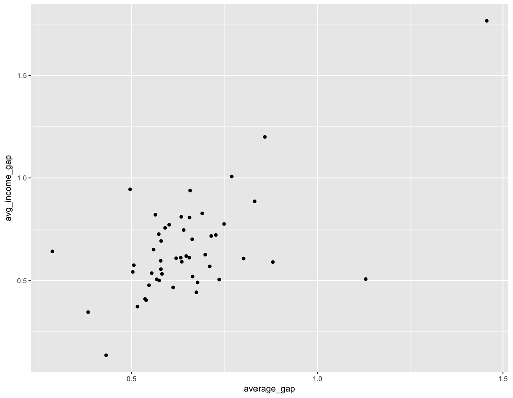

```r
library(ggplot2)

ggplot(summary_all, aes(average_gap, avg_income_gap)) + geom_point()
```

That’s a pretty strong chart. The wider the income gap of school districts in a state, the wider the test score gap.

The correlation coefficient is 0.624844 (you can figure this out by typing `cor(summary_all$avg_income_gap, summary_all$average_gap, use="complete")`)

How about the other factor that measured segregation?

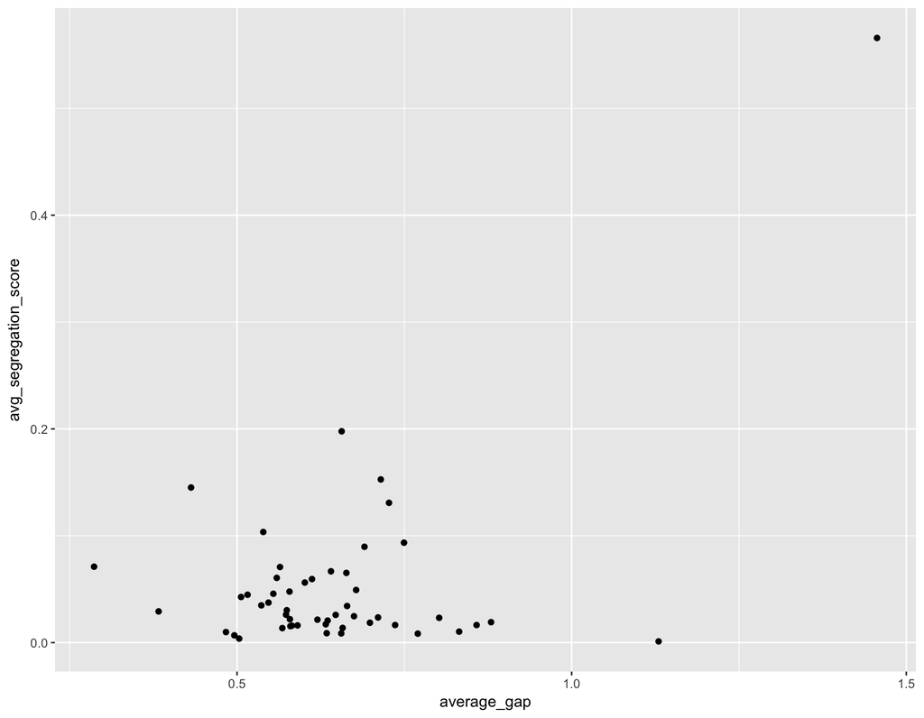

```r
ggplot(summary_all, aes(average_gap, avg_segregation_score)) + geom_point()
```

Well, this chart is less convincing.

It only has a correlation coefficient of 0.5199409 (`cor(summary_all$avg_segregation_score, summary_all$average_gap, use="complete")`).

This is just the beginning, though.

You could write a script to go through each of the factors in the `covariates` dataframe and compare them to the factors in the `test_gaps` dataframe. Or you could try to write a model that predicts the success of students based on those factrs (You’ll be walking in the footsteps of those who’ve done [lots of work](http://news.stanford.edu/2016/04/29/local-education-inequities-across-u-s-revealed-new-stanford-data-set/) on this topic already).

But this exercise was to get you to think about answering questions and test ideas with data and some functions in R using `dplyr` and `ggplot2`.

Before we go, let’s clean up the charts a little bit.

Every chart needs these aspects.

- Clean
- Clear labels
- A headline
- Sub title for context if necessary
- Source tag
- Byline

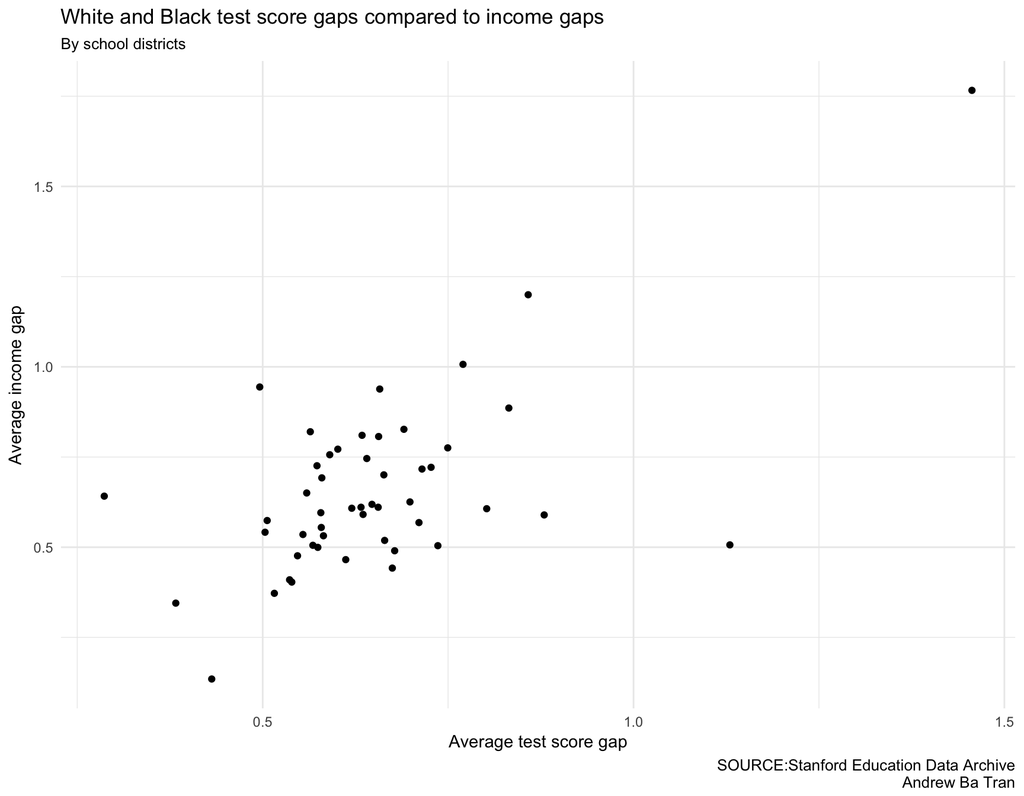

```r
gg <- ggplot(summary_all, aes(average_gap, avg_income_gap)) + geom_point()
gg <- gg + labs(x="Average test score gap", y="Average income gap", title="White and Black test score gaps compared to income gaps", subtitle="By school districts",
                caption="SOURCE:Stanford Education Data Archive\nAndrew Ba Tran")
gg <- gg + theme(panel.border=element_blank())
gg <- gg + theme(panel.grid.minor=element_blank())
gg <- gg + theme_minimal()
gg
```

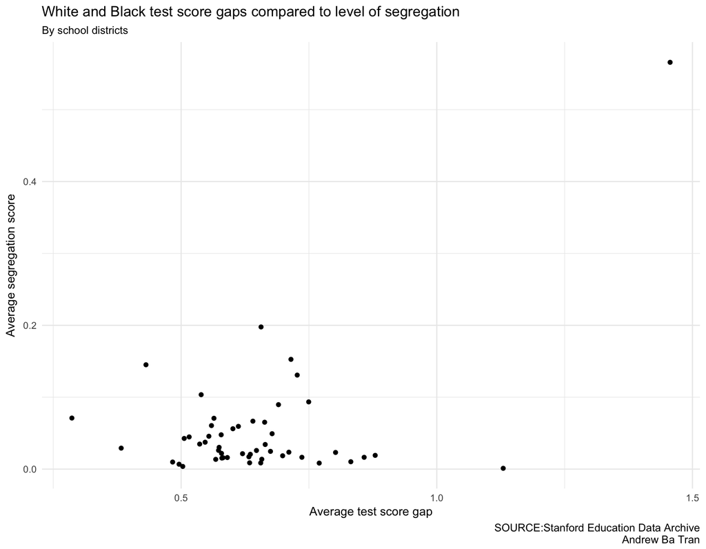

```r
gg <- ggplot(summary_all, aes(average_gap, avg_segregation_score)) + geom_point()
gg <- gg + labs(x="Average test score gap", y="Average segregation score", title="White and Black test score gaps compared to level of segregation", subtitle="By school districts",
                caption="SOURCE:Stanford Education Data Archive\nAndrew Ba Tran")
gg <- gg + theme(panel.border=element_blank())
gg <- gg + theme(panel.grid.minor=element_blank())
gg <- gg + theme_minimal()
gg
```